# A Step-by-Step Guide on How to Fit Marginalized Transition Models with a Longitudinal Ordinal and Binary Outcomes

Published

September 13, 2025

The development version of the `OMTM1` package is available on GitHub and can be installed using the `devtools` package:

```r
library(devtools)
devtools::install_github("schildjs/OMTM1")
```

Once installed, the package can be loaded with the `library` command:

```r
library(OMTM1)
```

In this guide, we will use a simulated dataset to demonstrate how the `OMTM1` package can be used to fit marginalized transition models with longitudinal binary and ordinal outcomes under a couple of scenarios described in the simulations of the accompanying paper. This document will be much easier to follow if you have already read the paper.

# The Data

The dataset includes 1000 simulated subjects measured across 28 follow-up days. Each day a participant can be in one of four ordered outcome states, `Y`$\in \{1, 2, 3, 4\}$, and for our purposes, state $k = 1$ is an absorbing state. For ease of coefficient interpretation, we log (base 28) the follow-up day, `logt`$=\log_{28}(j+1)$, where `time`$=j,\ j \in \{0, \dots, 27\}$. At the end of follow-up, `logt` has a value of one (i.e., $\log_{28}(28) = 1$).

Together with `Y` and `time`, the dataset includes a randomized treatment assignment `X` (with `X` $\in \{0, 1\}$) and a time-fixed, binary covariate `Z` (with `Z` $\in \{0, 1\}$) generated to be independent of `X`. Further information on the structure of data is reported below:

```r
d0 <- readRDS("d0.rds")
str(d0)
```

```
'data.frame':   28000 obs. of  6 variables:
 $ id  : int  1 1 1 1 1 1 1 1 1 1 ...
 $ X   : int  1 1 1 1 1 1 1 1 1 1 ...
 $ time: num  0 1 2 3 4 5 6 7 8 9 ...
 $ logt: num  0 0.208 0.33 0.416 0.483 ...
 $ Z   : num  1 1 1 1 1 1 1 1 1 1 ...
 $ Y   : num  2 2 2 1 1 1 1 1 1 1 ...
```

From the below table and figure, one can see that state $k = 1$ is absorbing, and overall there is a high probability of remaining in the same state from day to day.

|  | 1 | 2 | 3 | 4 |
| --- | --- | --- | --- | --- |
| 1 | 1 | 0.012 | 0.002 | 0.005 |
| 2 | 0 | 0.833 | 0.077 | 0.072 |
| 3 | 0 | 0.057 | 0.836 | 0.118 |
| 4 | 0 | 0.099 | 0.084 | 0.805 |

Day-to-day transition probabilities from the lagged state (columns) to the current state (rows)

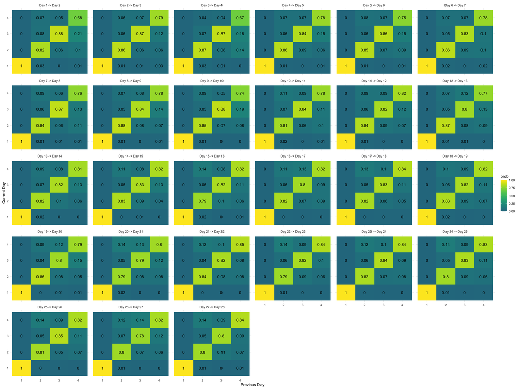

Day-to-day transition probabilities from the lagged state (columns) to the current state (rows)

# Fitting a Marginalized Transition Model with a Longitudinal Ordinal Outcome

## Assume Proportional Odds for the Treatment Effect

First, we fit a marginalized transition model with a longitudinal ordinal outcome while imposing the proportional odds (PO) assumption on the treatment effect. Let $i \in \{1, \dots,\ 1000\}$ denote subject, $j \in \{0, \dots, \ 27 \}$ denote follow-up time, and $t_{ij} = \log_{28}(j + 1)$. As we discuss in the paper, because we have an absorbing state, it is likely that the PO assumption for time will be violated, and so we relax the PO assumption associated with $t_{ij}$. The marginal component of the marginalized transition model is given by:

$${\rm logit}(P(Y_{ij} \leq k | X_i, Z_i))
= \alpha_{0, k} + t_{ij}[\beta_{t, 1} + \beta_{t,2}I(Y_{ij} = 2) + \beta_{t,3}I(Y_{ij} = 3)] + [\beta_{x} + \beta_{xt} t_{ij}] X_i + \beta_z Z_i$$

and the conditional, response-dependence component is given by,

$$\log\left(\frac{P(Y_{ij} = k | X_{i}, Z_{i}, Y_{i(j-1)})}{P(Y_{ij} = K | X_{i}, Z_{i}, Y_{i(j-1)})}\right) = \Delta_{ij,k}(X_{i}, Z_{i})+\sum_{l = 1}^{K-1}\gamma^{kl}(X_i, Z_i) I[Y_{i(j-1)} = l]$$

The model can be fit using the `omtm1` function. For the function to work, users will need to specify:

1. `params` a vector of starting values. The optimization algorithm embedded within `omtm1` will not run unless starting parameters are specified.

```r
inits <- c(# intercept
           -4.75, -1.5, 2,
           # coefficients for variables in XMat
           0, 2, -0.35, 2,  # beta.x, beta.t1, beta.xt, beta.z
           # coefficients for the non-proportionality term in x.ppo
           -1.75, -4,  # beta.t2, beta.t3
           # transition log relative risk ratios from the Gamma matrix (row major)
           25, 2, 1, -25, 4, 2, -25, 1, 4
           )
```

**Choosing the Initial Parameters Value**

The algorithm can be sensitive to the choice of the initial parameters. Below are some suggestions:

1. Fit a cross-sectional ordinal model using the function `vglm` in the `VGAM` package. Use the estimated coefficients as starting parameters for the intercept and the PO parameters.
2. Set the quantities for the non-proportional odds for time and the transition probabilities across states to 0. Note, the diagonal of the $\mathbf{\Gamma}$ will likely have positive values since the probability of remaining in the same state from day to day is often high.

If the model does not fit, one can increase or decrease the maximum step size of the maximization algorithm by changing `step.max` in the `omtm1` call. By default `step.max = 0.5`.

2. `yval`: vector of observed outcomes

```r
yval <- d0$Y
```

3. `XMat`: design matrix without the intercepts. The matrix needs to be ordered in the same way as the vector of observed outcomes

```r
XMat <- with(d0, cbind(X, logt, Xlogt = X*logt, Z))
```

4. `id`: vector of subject identifiers. The vector needs to be ordered in the same way as the vector of observed outcomes

```r
id <- d0$id
```

5. `ppo.k`: vector of outcome levels corresponding to non-proportionality parameters

```r
ppo.k <- c(2, 3)
```

6. `x.ppo`: design matrix for the non-proportional odds component of the model. The design matrix needs to have the same number of columns as the length of `ppo.k` and it needs to be ordered in the same way as the vector of observed outcomes. Because the PO assumption is removed for the time variable, then:

```r
x.ppo <- XMat[, c("logt", "logt")]
```

Note that if there are observations with missing values, `omtm1` will remove them by default. If the missingness is non-monotonic, one must carefully consider whether a transition model is appropriate. The `omtm1` allows the transition terms to depend on other variables (e.g., covariates or time separation between successive observations), but that is not covered here. Once all the elements are specified, the model can be fit as:

```r
mod <- omtm1(params = inits, yval = yval, XMat = XMat, id = id,
             ppo.k = ppo.k, x.ppo = x.ppo)
```

Here is output from the `mod` object.

```r
mod
```

```
$loglik
[1] -14491.11

$alpha
[1] -4.710005 -1.507364  1.972170

$beta
[1]  0.05473445  2.05925898 -0.39593968  2.02820724 -1.82383240 -4.03261951

$gamma
$gamma$`1`
     [,1]      [,2]     [,3]
[1,]   25 1.9038848 1.050457
[2,]  -25 3.9146186 2.060589
[3,]  -25 0.9817724 4.019037
```

[output cut: 113 more lines]

The `summary.omtm` function returns the coefficients and standard error estimates, the z-value, and the p-value testing whether the corresponding coefficient estimate is non-zero. Robust standard errors can be obtained by specifying `robust = TRUE` in the summary call.

```r
(sum.mod <- summary.omtm(mod))
```

```
$class
[1] "omtm"

$control
convergence_code           n_iter       n_subjects            n_obs
               1               43             1000            28000
        cond_ref
               4

$cs.table
                  Estimate     StdErr           Z       p.value
Intercept:Y<=1 -4.71000488 0.16472763 -28.5926822 8.284769e-180
Intercept:Y<=2 -1.50736397 0.09417048 -16.0067573  1.146304e-57
Intercept:Y<=3  1.97216999 0.11336167  17.3971495  8.671194e-68
b_1             0.05473445 0.11205659   0.4884537  6.252285e-01
b_2             2.05925898 0.16102301  12.7886005  1.898622e-37
b_3            -0.39593968 0.14176217  -2.7929854  5.222405e-03
b_4             2.02820724 0.05801565  34.9596547 9.237529e-268
b_5            -1.82383240 0.15609979 -11.6837598  1.543156e-31
b_6            -4.03261951 0.18317098 -22.0156022 2.041407e-107

$dependence.table
            Estimate       StdErr           Z       p.value
gamma:11  25.0000013 1.000000e+08  0.00000025  9.999998e-01
gamma:12   1.9038848 2.223040e-01  8.56433117  1.087050e-17
gamma:13   1.0504567 2.822893e-01  3.72120683  1.982730e-04
gamma:21 -25.0000000 1.000000e+08 -0.00000025  9.999998e-01
gamma:22   3.9146186 6.345821e-02 61.68813254  0.000000e+00
gamma:23   2.0605895 7.352950e-02 28.02398497 8.291517e-173
gamma:31 -25.0000000 1.000000e+08 -0.00000025  9.999998e-01
gamma:32   0.9817724 7.390410e-02 13.28440929  2.850994e-40
gamma:33   4.0190367 5.468827e-02 73.48992755  0.000000e+00

attr(,"class")
[1] "summary.omtm"
```

The `sum.mod` object is comprised of 4 components:

1. `$class`: class type of the `omtm1` output.
2. `$control`: includes convergence status outputted from the `nlm` minimizer (`convergence_code = 1` implies the model converged), the number of iterations run by the algorithm (`n_iter`), the number of unique individuals in the data (`n_subjects`), the number of rows in the data (`n_obs`), and the reference state used in the conditional, response-dependence component of the model for the lagged response.
3. `$cs.table`: estimated coefficients, standard errors, z-values and p-values for the coefficient in the marginal component of the model. Note that the coefficients are ordered as follows:
   - Estimated intercepts
   - Estimated coefficients for the variables in `XMat` (b_1 to b_4).
   - Estimated coefficients associated with the non-PO coefficients (b_5 and b_6). These will depend on both `ppo.k` and `x.ppo`. In this case, because `ppo.k <- c(2, 3)` and `x.ppo <- cbind(d0$logt, d0$logt)`, b_5 represents the additional association term for `logt` (to be added to b_2) needed for the $Y \in \{1, 2\}$ versus $Y \in \{3, 4\}$ outcome dichotomization while b_6 represents the additional association term for association with `logt` (to be added to b_2) needed for the $Y \in \{1, 2, 3\}$ versus $Y \in \{4\}$ outcome dichotomization.
4. `$dependence.table`: estimated coefficients, standard errors, z-values and p-values for the coefficients in the conditional, response-dependence component of the model

By default, `omtm1` assumes that the PO assumption holds for all variables, so if we want to assume PO for the `logt` association, we would remove all terms associated with non-proportional odds as shown below:

```r
inits.po <- c(# intercept
             -4.75, -1.5, 2,
             # coefficients of variables in the design matrix
             0, 2, -0.35, 2,
             # log-risk ratio for transition probabilities across states
             25, 2, 1, -25, 4, 2, -25, 1, 4
             )

mod.po <- omtm1(params = inits.po, yval = yval, XMat = XMat, id = id)
```

**Further Details on Outcome Specification**

The `omtm1` function requires the outcome to be numeric (i.e., at each time point $Y$ needs to be an integer greater than 0). Thus, users would need to modify the outcome vector if coded differently.

**Select a Reference Level for the Lagged Response in the Transition Matrix**

By default, `omtm1` chooses the highest outcome value state (4 in our example) as the reference for $Y_{i,j-1}$ in the conditional, response dependence model. Users can change the reference state by specifying the argument `ref.muc` in `omtm1`. For instance, the code chunk below changes the reference for $Y_{i,j-1}$ in the conditional, response-dependence model to state $3$.

```r
omtm1(params = inits, yval = yval, XMat = XMat, id = id,
      ppo.k = c(2, 3), x.ppo = x.ppo, ref.muc = 3)
```

Note that changes in `ref.muc` will not affect the coefficients $\mathbf{\alpha}$ and $\mathbf{\beta}$ in the marginal component of the model, but because the reference state has changed, it will have an impact on the estimated dependence model parameters. Notably, it is the same model, just with a different reference state for $Y_{i,j-1}$ in the response dependence model.

## Relaxing the Proportional Odds Assumption for the Treatment Effect

We can relax the proportional odds assumption for the treatment effect as well as other associations in the model. In order to do so, we modify `params`, `x.ppo`, `ppo.k`. For instance, if we want to relax the PO assumption for the treatment effect across all dichotomizations of the outcome and fit the following model

$$\begin{align*}
{\rm logit}(P(Y_{ij} \leq k | X_i, Z_i))
&= \alpha_{0,k}
+ t_{ij}[\beta_{t,1} + \beta_{t,2}I(Y_{ij} = 2) + \beta_{t,3}I(Y_{ij} = 3)] \\
&+ [\beta_{x} + \{\beta_{xt,1} + \beta_{xt,2}I(Y_{ij} = 2) + \beta_{xt,3}I(Y_{ij} = 3) \} t_{ij}] X_i
+ \beta_z Z_i
\end{align*}$$

$$\log\left(\frac{P(Y_{ij} = k | X_{i}, Z_{i}, Y_{i(j-1)})}{P(Y_{ij} = K | X_{i}, Z_{i}, Y_{i(j-1)})}\right) = \Delta_{ij,k}(X_{i}, Z_{i})+\sum_{l = 1}^{K-1}\gamma^{kl}(X_i, Z_i) I[Y_{i(j-1)} = l],$$

we would specify the arguments as follows:

```r
# initial parameter values

inits.ppo <- c(# intercept
               -4.75, -1.5, 2,
               # coefficients of variables in the XMat matrix
               0, 2, -0.35, 2,
               # coefficients for terms in x.ppo2
               -1.75, -4, 0, 0,  # first 2 are for time and last 2 are for treatment effect
               # log relative risk ratio for transition probabilities across states
               25, 2, 1, -25, 4, 2, -25, 1, 4
               )

# vector of outcome levels for which the PO assumption is relaxed
# the first (2, 3) represent the relaxation of the PO assumption for time,
# the second (2, 3) represent the relaxation of the PO assumption for treatment,
ppo.k2 <- c(2, 3, 2, 3)

# new design matrix for the partial PPO part
x.ppo2 <- XMat[, c("logt", "logt", "Xlogt", "Xlogt")]

mod.ppo <- omtm1(params = inits.ppo, yval = yval, XMat = XMat, id = id,
                 ppo.k = ppo.k2, x.ppo = x.ppo2)
```

All other inputs are the same as those specified in `mod`. Results can be obtained and interpreted as described above:

```r
summary.omtm(mod.ppo)
```

```
$class
[1] "omtm"

$control
convergence_code           n_iter       n_subjects            n_obs
               1               48             1000            28000
        cond_ref
               4

$cs.table
                  Estimate    StdErr           Z       p.value
Intercept:Y<=1 -4.71158503 0.1652185 -28.5172987 7.149493e-179
Intercept:Y<=2 -1.50507380 0.0951463 -15.8185208  2.318765e-56
Intercept:Y<=3  1.97460819 0.1141986  17.2910000  5.499002e-67
b_1             0.05066504 0.1154987   0.4386632  6.609056e-01
b_2             2.08211951 0.1711909  12.1625560  4.919498e-34
b_3            -0.44043445 0.1784428  -2.4682103  1.357905e-02
b_4             2.02727326 0.0580296  34.9351591 2.175905e-267
b_5            -1.87215920 0.1697401 -11.0295620  2.752020e-28
b_6            -4.03974807 0.1999693 -20.2018432  9.431053e-91
b_7             0.09292072 0.1266814   0.7334995  4.632538e-01
b_8             0.01363958 0.1531627   0.0890529  9.290399e-01

$dependence.table
            Estimate       StdErr           Z       p.value
gamma:11  25.0000015 1.000000e+08  0.00000025  9.999998e-01
gamma:12   1.9045828 2.223142e-01  8.56707478  1.061470e-17
gamma:13   1.0490810 2.822733e-01  3.71654368  2.019667e-04
gamma:21 -25.0000000 1.000000e+08 -0.00000025  9.999998e-01
gamma:22   3.9145016 6.345754e-02 61.68694167  0.000000e+00
gamma:23   2.0603678 7.353081e-02 28.02046766 9.151528e-173
gamma:31 -25.0000000 1.000000e+08 -0.00000025  9.999998e-01
gamma:32   0.9821608 7.390712e-02 13.28912285  2.676979e-40
gamma:33   4.0191165 5.468946e-02 73.48977663  0.000000e+00

attr(,"class")
[1] "summary.omtm"
```

If we want to fit a marginalized transition model where the treatment effect for the $k = 1$ vs $k > 1$ dichotomization differs from a common treatment effect for the $k \in \{1,2\}$ vs $k \in \{3,4\}$ and $k \in \{1,2,3\}$ vs $k \in \{4\}$ as in

$$\begin{align*}
{\rm logit}(P(Y_{ij} \leq k | X_i, Z_i))
&= \alpha_{0,k}
+ t_{ij}[\beta_{t,1} + \beta_{t,2}I(Y_{ij} = 2) + \beta_{t,3}I(Y_{ij} = 3)] \\
&+ [\beta_{x} + \{\beta_{xt,1} + \beta_{xt,2}I(Y_{ij} \in \{2, 3\}) \} t_{ij}] X_i
+ \beta_z Z_i
\end{align*}$$

$$\log\left(\frac{P(Y_{ij} = k | X_{i}, Z_{i}, Y_{i(j-1)})}{P(Y_{ij} = K | X_{i}, Z_{i}, Y_{i(j-1)})}\right) = \Delta_{ij,k}(X_{i}, Z_{i})+\sum_{l = 1}^{K-1}\gamma^{kl}(X_i, Z_i) I[Y_{i(j-1)} = l],$$
it is simplest to reverse the ordering of the outcome (1 becomes 4, 2 becomes 3, 3 becomes 2, and 4 becomes 1). As expected, this will reverse the signs of all coefficients. As before, we would need to change `params`, `x.ppo`, `ppo.k`. In particular:

1. In `params`, we need to reverse the order of the intercept as well as the sign of the coefficients. Note that we only need to specify one additional coefficient for the treatment effect in the PO part as we are assuming a common treatment effect for the dichotomizations at $k = 2$ and $k = 3$.

```r
# flip the outcome
Y.flip <- abs(yval - 5)

inits.ppo2 <- c(# intercept
                -rev(c(-4.75, -1.5, 2)),
                # coefficients of variables in the XMat matrix
                -0, -(2 + (-4)), -(-0.35), -2,
                # Non-proportional odds terms corresponding to x.ppo3
                -4 - (-1.75), -4, 0,  # first 2 for time, the last one for treatment effect
                # log relative risk ratio for transition probabilities
                rev(c(25, 2, 1, -25, 4, 2, -25, 1, 4))
                )
```

2. In `ppo.k` and `xx.ppo` we would need to specify the PO assumption for time and the common treatment effect between $k = 2$ and $k = 3$.

```r
ppo.k3 <- c(2, 3, 3)

# new design matrix for the partial PPO part
x.ppo3 <- XMat[, c("logt", "logt", "Xlogt")]

mod.ppo <- omtm1(params = inits.ppo2, yval = Y.flip, XMat = XMat, id = id,
                 ppo.k = ppo.k3, x.ppo = x.ppo3, ref.muc = 2)
```

# Fitting a Marginalized Transition Model with a Longitudinal Binary Outcome

The `omtm1` function can be used to fit marginalized transition model with a binary longitudinal outcome. First, we need to define the outcome $Y$ so that it can take only value 1 if an individual in the study experienced the event and 2 otherwise.

```r
Y.bin <- ifelse(yval %in% c(2, 3, 4), 2, 1)
```

Then, we can use a simplified version of the model under the PO assumption as below:

```r
# initial parameter values
inits.bin <- c(# intercept
               -4.75,
               # coefficients of variables in the design matrix
               0, 2, -0.35, 2,
               # log-odds ratio for transitions from the lagged to current state
               25)

mod.bin <- omtm1(params = inits.bin, yval = Y.bin, XMat = XMat, id = id)

summary.omtm(mod.bin)
```

```
$class
[1] "omtm"

$control
convergence_code           n_iter       n_subjects            n_obs
               1               23             1000            28000
        cond_ref
               2

$cs.table
                 Estimate    StdErr           Z      p.value
Intercept:Y<=1 -4.4403784 0.2711789 -16.3743535 2.915891e-60
b_1            -0.2173881 0.3121418  -0.6964403 4.861531e-01
b_2             1.9722322 0.1986909   9.9261341 3.204391e-23
b_3            -0.2559372 0.2882929  -0.8877679 3.746656e-01
b_4             1.8771116 0.2066342   9.0842245 1.044405e-19

$dependence.table
         Estimate StdErr       Z   p.value
gamma:11       25  1e+08 2.5e-07 0.9999998

attr(,"class")
[1] "summary.omtm"
```